# Feeling protected from COVID-19 at work

Dataset 2: COVID-19 workplace protection survey

RSR feasibility analysis

2026-08-03

# Introduction

Workplaces were the main setting in which working-age adults were exposed to SARS-CoV-2, and whether staff *believed* their employer’s control measures were working mattered for adherence, for morale and for staff retention. These data come from the international validation study of a multi-lingual online questionnaire on COVID-19 prevention and control measures in workplaces (Ingram et al., *BMC Public Health* 2022;22:74), in which workers in eight countries were recruited by non-probability convenience sampling. The catalogue file contains the 557 records in the deposited complete-demographics sheet, each a single worker reporting whether they feel protected from COVID-19 at work.

**Aim.** Among these employed adults, we examined which of vaccination status, holding a management role, sex, education, age group, country of residence and occupational sector are independently associated with the odds of feeling protected from COVID-19 at work, mutually adjusting for the others.

This is a *Purpose 3* analysis: several predictors are of interest and the question is which remain associated with the outcome after mutual adjustment.

# Methods

**Data source.** International cross-sectional online survey of workers, recruited through non-probability convenience sampling in eight countries; the deposited demographic sheet supplies 557 respondents, each measured once. There is no follow-up and no sampling frame.

**Variables.** The outcome is `feels_protected`, a yes/no answer to whether the respondent feels protected from COVID-19 at work; “Yes” is treated as the event, so odds ratios above 1 mean *more* likely to feel protected. In the analysed file 326 of 557 respondents (58.5%) feel protected and 231 (41.5%) do not. Predictors are all categorical: `vaccination_status` (reference: vaccinated, the largest group; the other levels are no vaccine access and vaccine refusal), `management_role` (reference: no), `sex` (reference: female, the larger group), `college_degree` (reference: no degree), `age_group` in years (reference: <35, the youngest band), `country_grp` (reference: Canada, the largest group) and `sector_grp` (reference: health care, the largest group). There are no continuous predictors, so no units apply. `id` is a row identifier and is excluded from every model.

**Collapsing sparse categories.** Two predictors arrive with far more levels than this sample can support. `country` has 7 levels, of which 4 contain fewer than 25 respondents (United Kingdom 44, China 24, Argentina 21, Nigeria 19, Poland 18), against Canada 237 and Ireland 194. `occupational_sector` has 10 levels, of which 7 contain fewer than 28 respondents, the smallest being transport (13) and manufacturing (13), and manufacturing splits 1 against 12 on the outcome — one cell of size one. Entered raw, these two variables alone would contribute 15 of the 23 estimated coefficients and would produce odds ratios with confidence intervals spanning one to two orders of magnitude. We therefore collapsed them *before* looking at any model: `country` into Canada / Ireland / other country, and `occupational_sector` into health care / education / other sector. The kept levels are the two largest countries and the two largest sectors; education is kept separate from “other” because teaching was a distinct exposure setting during the pandemic and it is the second-largest sector. The collapsing rule is based on cell sizes and subject matter, not on which grouping gave the nicest p-value. The uncollapsed model is fitted once below purely to show the reader what was avoided.

**Statistical analysis.** Logistic regression (`glm(family = binomial)`), justified because the outcome is binary. We fitted a univariable model for each predictor first, then a single multivariable model containing all of them. Predictors were chosen in advance on subject-matter grounds, not by significance. Results are reported as odds ratios with 95% profile-likelihood confidence intervals; significance threshold 0.05. Model fit is summarised with AIC and events per parameter. Assumptions were checked with `performance::check_model()`. Analysis used R version 4.6.0 (2026-04-24) with tidyverse, gtsummary and performance.

**Missing data.** There is none. All nine columns are 100% complete, so the complete-case model uses all 557 of 557 rows and 0 rows were dropped. No imputation, no missingness mechanism to argue about, and no difference between the crude and adjusted analytic samples.

# Results

## Sample characteristics

**Table 1. Sample characteristics by whether the respondent feels protected from COVID-19 at work.**

| **Characteristic** | **N** | **No** N = 231<sup>1</sup> | **Yes** N = 326<sup>1</sup> |
| --- | --- | --- | --- |
| vaccination_status | 557 |  |  |
| Vaccinated |  | 176 (76%) | 264 (81%) |
| No vaccine access |  | 30 (13%) | 32 (9.8%) |
| Vaccine refusal |  | 25 (11%) | 30 (9.2%) |
| management_role | 557 | 41 (18%) | 132 (40%) |
| sex | 557 |  |  |
| Female |  | 186 (81%) | 221 (68%) |
| Male |  | 45 (19%) | 105 (32%) |
| college_degree | 557 | 185 (80%) | 241 (74%) |
| age_group | 557 |  |  |
| <35 |  | 59 (26%) | 59 (18%) |
| 35-45 |  | 66 (29%) | 78 (24%) |
| 45-55 |  | 62 (27%) | 101 (31%) |
| >55 |  | 44 (19%) | 88 (27%) |
| country_grp | 557 |  |  |
| Canada |  | 104 (45%) | 133 (41%) |
| Ireland |  | 75 (32%) | 119 (37%) |
| Other country |  | 52 (23%) | 74 (23%) |
| sector_grp | 557 |  |  |
| Health care |  | 86 (37%) | 145 (44%) |
| Education |  | 53 (23%) | 39 (12%) |
| Other sector |  | 92 (40%) | 142 (44%) |

<sup>1</sup> n (%)

326 of 557 respondents (58.5%) feel protected, so the two outcome groups are reasonably balanced and the rarer class contains 231 people. The sample is not balanced on its predictors, however: it is 73% female, 76% college-educated, 79% vaccinated, and 77% of respondents live in Canada or Ireland. The clearest group differences in Table 1 are that managers and men are over-represented among those who feel protected, and education-sector workers among those who do not.

## Exploratory figure

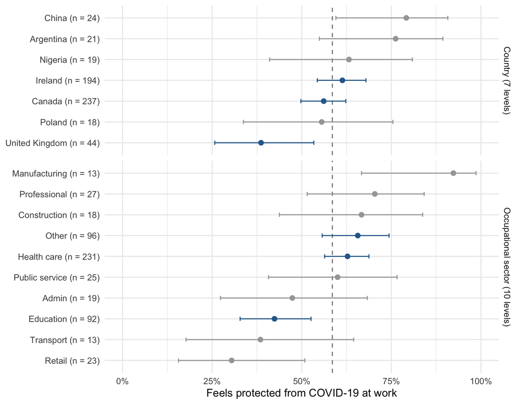

Figure 1. Proportion feeling protected from COVID-19 at work, by country (7 original levels) and by occupational sector (10 original levels). Points are observed proportions, bars are 95% Wilson confidence intervals, the number beside each label is the group size, and the dashed line is the overall proportion. Groups plotted in grey have fewer than 30 respondents.

The figure shows both a signal and a problem. The signal is that education, retail and transport workers report feeling protected far less often than health care workers, and that the education contrast rests on a group of 92 people, which is large enough to take seriously. The problem is everything drawn in grey: the confidence interval for manufacturing runs from about 67% to 99%, and China, Argentina, Nigeria and Poland have intervals between 31 and 42 percentage points wide, against 13 for Canada. Those groups cannot support their own coefficient, which is why country and sector were collapsed before modelling.

## Univariable models

| **Characteristic** | **N** | **OR** | **95% CI** | **p-value** |
| --- | --- | --- | --- | --- |
| vaccination_status | 557 |  |  |  |
| Vaccinated |  | — | — |  |
| No vaccine access |  | 0.71 | 0.42, 1.22 | 0.2 |
| Vaccine refusal |  | 0.80 | 0.46, 1.42 | 0.4 |
| management_role | 557 |  |  |  |
| No |  | — | — |  |
| Yes |  | 3.15 | 2.12, 4.76 | <0.001 |
| sex | 557 |  |  |  |
| Female |  | — | — |  |
| Male |  | 1.96 | 1.32, 2.95 | <0.001 |
| college_degree | 557 |  |  |  |
| No |  | — | — |  |
| Yes |  | 0.70 | 0.47, 1.05 | 0.092 |
| age_group | 557 |  |  |  |
| <35 |  | — | — |  |
| 35-45 |  | 1.18 | 0.73, 1.93 | 0.5 |
| 45-55 |  | 1.63 | 1.01, 2.64 | 0.046 |
| >55 |  | 2.00 | 1.20, 3.35 | 0.008 |
| country_grp | 557 |  |  |  |
| Canada |  | — | — |  |
| Ireland |  | 1.24 | 0.84, 1.83 | 0.3 |
| Other country |  | 1.11 | 0.72, 1.73 | 0.6 |
| sector_grp | 557 |  |  |  |
| Health care |  | — | — |  |
| Education |  | 0.44 | 0.27, 0.71 | <0.001 |
| Other sector |  | 0.92 | 0.63, 1.33 | 0.6 |

Abbreviations: CI = Confidence Interval, OR = Odds Ratio

Two predictors dominate the crude picture. Holding a management role more than triples the odds of feeling protected (OR 3.15, 95% CI 2.12 to 4.76, p < 0.001), and men have roughly double the odds of women (OR 1.96, 95% CI 1.32 to 2.95, p < 0.001). Working in the education sector rather than health care roughly halves them (OR 0.44, 95% CI 0.27 to 0.71, p < 0.001), while the pooled “other sector” group is indistinguishable from health care (OR 0.92, 95% CI 0.63 to 1.33, p = 0.643). Feeling protected rises steadily with age: relative to workers under 35, the 45-55 band has OR 1.63, 95% CI 1.01 to 2.64, p = 0.046 and the over-55 band OR 2.00, 95% CI 1.20 to 3.35, p = 0.008.

The predictor of most substantive interest behaves least interestingly. Vaccination status shows no crude association with feeling protected: relative to vaccinated respondents, those with no access to a vaccine have OR 0.71, 95% CI 0.42 to 1.22, p = 0.210 and those who refused vaccination have OR 0.80, 95% CI 0.46 to 1.42, p = 0.438. Both point estimates sit below 1 and both intervals comfortably include it. Country contributes nothing either, once collapsed (Ireland versus Canada, OR 1.24, 95% CI 0.84 to 1.83, p = 0.274), and holding a college degree is at most weakly and negatively associated (OR 0.70, 95% CI 0.47 to 1.05, p = 0.092).

## Why adjustment is needed

The crude estimates above are mutually contaminated in at least two concrete ways in *this* file. First, **`sex` confounds the `management_role` association**. The sample is 73% female overall but only 61% female among managers, and men are crudely more likely to feel protected regardless of their role, so part of the apparent management effect is simply that managers are disproportionately men. The reverse also holds: part of the crude male advantage is that men are more often managers. Second, **`sector_grp` confounds both `sex` and `age_group`**. Health care and education have very different sex compositions here (84% female in health care versus 61% in the other-sector group) and very different outcome rates, so a sex comparison that ignores sector is partly a comparison of industries. Third, **`country_grp` and `sector_grp` confound each other severely**, because recruitment was country-specific and sector-specific at the same time: only 11% of Canadian and 5% of Irish respondents work in education, against 44% of the other-country group, and education is the sector with much the lowest rate of feeling protected. A crude country comparison is therefore substantially a comparison of which industries happened to be recruited where — which is why the Ireland coefficient changes direction once sector is held constant. Only a model holding all seven predictors constant lets any one of them be read as a within-stratum comparison.

## Multivariable model

| **Characteristic** | **OR** | **95% CI** | **p-value** |
| --- | --- | --- | --- |
| vaccination_status |  |  |  |
| Vaccinated | — | — |  |
| No vaccine access | 0.61 | 0.33, 1.11 | 0.10 |
| Vaccine refusal | 0.74 | 0.39, 1.40 | 0.4 |
| management_role |  |  |  |
| No | — | — |  |
| Yes | 3.20 | 2.07, 5.03 | <0.001 |
| sex |  |  |  |
| Female | — | — |  |
| Male | 1.84 | 1.18, 2.88 | 0.007 |
| college_degree |  |  |  |
| No | — | — |  |
| Yes | 0.74 | 0.46, 1.16 | 0.2 |
| age_group |  |  |  |
| <35 | — | — |  |
| 35-45 | 1.22 | 0.72, 2.06 | 0.5 |
| 45-55 | 1.51 | 0.91, 2.54 | 0.11 |
| >55 | 1.82 | 1.04, 3.21 | 0.037 |
| country_grp |  |  |  |
| Canada | — | — |  |
| Ireland | 0.89 | 0.56, 1.40 | 0.6 |
| Other country | 1.29 | 0.75, 2.24 | 0.4 |
| sector_grp |  |  |  |
| Health care | — | — |  |
| Education | 0.32 | 0.17, 0.58 | <0.001 |
| Other sector | 0.67 | 0.43, 1.03 | 0.067 |

Abbreviations: CI = Confidence Interval, OR = Odds Ratio

Model fit

| Statistic | Value |
| --- | --- |
| AIC (fitted model) | 713.1 |
| AIC (intercept-only model) | 757.9 |
| Null deviance | 755.9 |
| Residual deviance | 687.1 |
| Likelihood-ratio test vs null (p) | 5.36e-10 |
| Tjur's R2 | 0.115 |
| N | 557 |
| Events (feels protected) | 326 |
| Non-events | 231 |
| Rarer outcome class | 231 |
| Model parameters (incl. intercept) | 13 |
| Events per parameter | 19.2 |

The model estimates 12 coefficients besides the intercept, and the smaller outcome class contains 231 observations, giving about 19.2 events per parameter — comfortably above the conventional minimum of 10, so the collapsed model is not overfitted. It beats the intercept-only model (AIC 713.1 versus 757.9; likelihood-ratio test p < 0.001), but explains little: Tjur’s R² is 0.115, meaning the average predicted probability of feeling protected differs by only about 12 percentage points between those who do and those who do not.

Conditional on all the other predictors, three associations survive. Managers have OR 3.20, 95% CI 2.07 to 5.03, p < 0.001 — the single strongest and most robust finding in the dataset. Men have OR 1.84, 95% CI 1.18 to 2.88, p = 0.007. Education-sector workers have OR 0.32, 95% CI 0.17 to 0.58, p < 0.001 relative to health care, and the other-sector group OR 0.67, 95% CI 0.43 to 1.03, p = 0.067. Age retains a gradient but only the oldest band clears the threshold (OR 1.82, 95% CI 1.04 to 3.21, p = 0.037 for over-55 versus under-35, with OR 1.51, 95% CI 0.91 to 2.54, p = 0.114 at 45-55). Neither country contrast is significant (Ireland OR 0.89, 95% CI 0.56 to 1.40, p = 0.606), and neither is holding a degree (OR 0.74, 95% CI 0.46 to 1.16, p = 0.195).

Vaccination status remains null after adjustment, and the two non-reference levels remain distinct from one another in the direction one would expect but without precision to speak of: no vaccine access OR 0.61, 95% CI 0.33 to 1.11, p = 0.103 and vaccine refusal OR 0.74, 95% CI 0.39 to 1.40, p = 0.353. A likelihood-ratio test of dropping the whole variable gives p = 0.213, so on these data vaccination status adds nothing to a model of feeling protected. It is worth stating explicitly that the two levels were *not* collapsed: lacking access to a vaccine and refusing one are different states — one is a supply failure, the other a choice — and pooling them would assume the very thing an analyst would want to test.

What the uncollapsed model looks like

Country (7 levels) and occupational sector (10 levels) entered raw; 23 coefficients, 10 events per parameter

| Term | OR | 95% CI | CI width (x) |
| --- | --- | --- | --- |
| countryIreland | 0.80 | 0.5 to 1.29 | 2.6 |
| countryUnited Kingdom | 0.75 | 0.32 to 1.74 | 5.5 |
| countryChina | 4.36 | 1.42 to 15.5 | 10.9 |
| countryArgentina | 1.56 | 0.48 to 5.79 | 12.0 |
| countryNigeria | 0.74 | 0.22 to 2.64 | 12.2 |
| countryPoland | 0.82 | 0.25 to 2.69 | 10.6 |
| sector_rawOther | 0.91 | 0.52 to 1.61 | 3.1 |
| sector_rawEducation | 0.31 | 0.16 to 0.6 | 3.8 |
| sector_rawProfessional | 0.93 | 0.37 to 2.51 | 6.8 |
| sector_rawPublic service | 0.58 | 0.23 to 1.51 | 6.5 |
| sector_rawRetail | 0.18 | 0.06 to 0.47 | 8.0 |
| sector_rawAdmin | 0.49 | 0.17 to 1.38 | 8.1 |
| sector_rawConstruction | 0.52 | 0.17 to 1.76 | 10.5 |
| sector_rawTransport | 0.21 | 0.06 to 0.76 | 13.7 |
| sector_rawManufacturing | 2.33 | 0.4 to 44.39 | 110.9 |

This is the model that was avoided. Fifteen of its 23 coefficients come from country and sector alone, events per parameter falls to 10 — exactly on the conventional floor — and several intervals are unusable: the manufacturing coefficient has a confidence interval spanning a 111-fold range and the China coefficient a roughly 11-fold range, because each rests on 13 and 24 people respectively. Honesty requires noting that the uncollapsed model does fit better in a formal sense (AIC 706.6 versus 713.1; likelihood-ratio test for the extra 11 coefficients p = 0.003), driven by the three or four small groups with extreme proportions. That is a real cost of collapsing, and it is a genuine trade-off rather than a free lunch: the collapsed model gives interpretable, stable estimates for the contrasts it reports, at the price of averaging over heterogeneity it cannot resolve at this sample size.

## Unadjusted versus adjusted

**Table 2. Unadjusted and adjusted odds ratios.**

| **Characteristic** | **Unadjusted** **N** | **Unadjusted** **OR** | **Unadjusted** **95% CI** | **Unadjusted** **p-value** | **Adjusted** **OR** | **Adjusted** **95% CI** | **Adjusted** **p-value** |
| --- | --- | --- | --- | --- | --- | --- | --- |
| vaccination_status | 557 |  |  |  |  |  |  |
| Vaccinated |  | — | — |  | — | — |  |
| No vaccine access |  | 0.71 | 0.42, 1.22 | 0.2 | 0.61 | 0.33, 1.11 | 0.10 |
| Vaccine refusal |  | 0.80 | 0.46, 1.42 | 0.4 | 0.74 | 0.39, 1.40 | 0.4 |
| management_role | 557 |  |  |  |  |  |  |
| No |  | — | — |  | — | — |  |
| Yes |  | 3.15 | 2.12, 4.76 | <0.001 | 3.20 | 2.07, 5.03 | <0.001 |
| sex | 557 |  |  |  |  |  |  |
| Female |  | — | — |  | — | — |  |
| Male |  | 1.96 | 1.32, 2.95 | <0.001 | 1.84 | 1.18, 2.88 | 0.007 |
| college_degree | 557 |  |  |  |  |  |  |
| No |  | — | — |  | — | — |  |
| Yes |  | 0.70 | 0.47, 1.05 | 0.092 | 0.74 | 0.46, 1.16 | 0.2 |
| age_group | 557 |  |  |  |  |  |  |
| <35 |  | — | — |  | — | — |  |
| 35-45 |  | 1.18 | 0.73, 1.93 | 0.5 | 1.22 | 0.72, 2.06 | 0.5 |
| 45-55 |  | 1.63 | 1.01, 2.64 | 0.046 | 1.51 | 0.91, 2.54 | 0.11 |
| >55 |  | 2.00 | 1.20, 3.35 | 0.008 | 1.82 | 1.04, 3.21 | 0.037 |
| country_grp | 557 |  |  |  |  |  |  |
| Canada |  | — | — |  | — | — |  |
| Ireland |  | 1.24 | 0.84, 1.83 | 0.3 | 0.89 | 0.56, 1.40 | 0.6 |
| Other country |  | 1.11 | 0.72, 1.73 | 0.6 | 1.29 | 0.75, 2.24 | 0.4 |
| sector_grp | 557 |  |  |  |  |  |  |
| Health care |  | — | — |  | — | — |  |
| Education |  | 0.44 | 0.27, 0.71 | <0.001 | 0.32 | 0.17, 0.58 | <0.001 |
| Other sector |  | 0.92 | 0.63, 1.33 | 0.6 | 0.67 | 0.43, 1.03 | 0.067 |

Abbreviations: CI = Confidence Interval, OR = Odds Ratio

The honest summary of this table is that adjustment changes remarkably little. Two estimates do move meaningfully. The **education sector** contrast moves *away* from the null, from 0.44 crude to 0.32 adjusted: education workers are more often female and less often managers than health care workers, and both of those characteristics independently lower the odds of feeling protected, so the crude comparison *understated* the sector gap. The **45-55 age band** moves towards the null and loses significance, from 1.63 (p = 0.046) to 1.51 (p = 0.114); that crude association was partly the fact that middle-aged respondents are more often managers. The **other-sector** contrast also moves from 0.92 to 0.67, though it never reaches significance in either column. **Ireland versus Canada** changes direction, from 1.24 to 0.89, and the other-country contrast from 1.11 to 1.29; neither is significant in either column, but the flip is exactly what the sector composition predicts — the Irish respondents are disproportionately health care workers and the other-country respondents disproportionately education workers, so the crude country comparison was carrying the sector effect.

Against that, the headline predictors barely move at all. Management goes from 3.15 to 3.20 — a change of about 1% — and sex from 1.96 to 1.84. Vaccination status is null in both columns and country is null in both columns. So the mutual confounding argued for above is real but small: it matters for the sector and age contrasts and is essentially irrelevant for the two strongest predictors. Nothing here is collinearity — every VIF is below 1.7 — and because the file is complete, the unadjusted and adjusted columns are computed on exactly the same 557 people, so none of the movement is a change of sample.

## Diagnostics

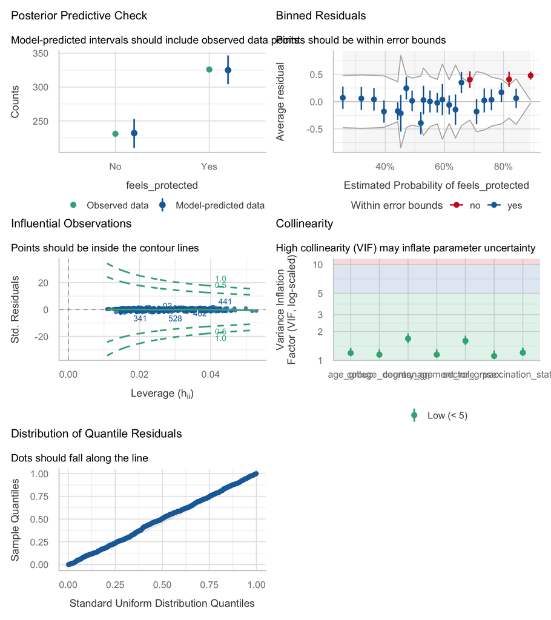

| Term | VIF | VIF_CI_low | VIF_CI_high | SE_factor | Tolerance | Tolerance_CI_low | Tolerance_CI_high |
| --- | --- | --- | --- | --- | --- | --- | --- |
| vaccination_status | 1.203288 | 1.116275 | 1.355415 | 1.096945 | 0.8310564 | 0.7377812 | 0.8958366 |
| management_role | 1.146537 | 1.071865 | 1.298796 | 1.070765 | 0.8721918 | 0.7699437 | 0.9329532 |
| sex | 1.109585 | 1.044631 | 1.269073 | 1.053368 | 0.9012377 | 0.7879768 | 0.9572761 |
| college_degree | 1.145779 | 1.071289 | 1.298104 | 1.070411 | 0.8727686 | 0.7703545 | 0.9334549 |
| age_group | 1.192295 | 1.107518 | 1.343917 | 1.091923 | 0.8387187 | 0.7440936 | 0.9029198 |
| country_grp | 1.685337 | 1.518331 | 1.906154 | 1.298205 | 0.5933530 | 0.5246167 | 0.6586179 |
| sector_grp | 1.597586 | 1.444211 | 1.803916 | 1.263956 | 0.6259445 | 0.5543494 | 0.6924195 |

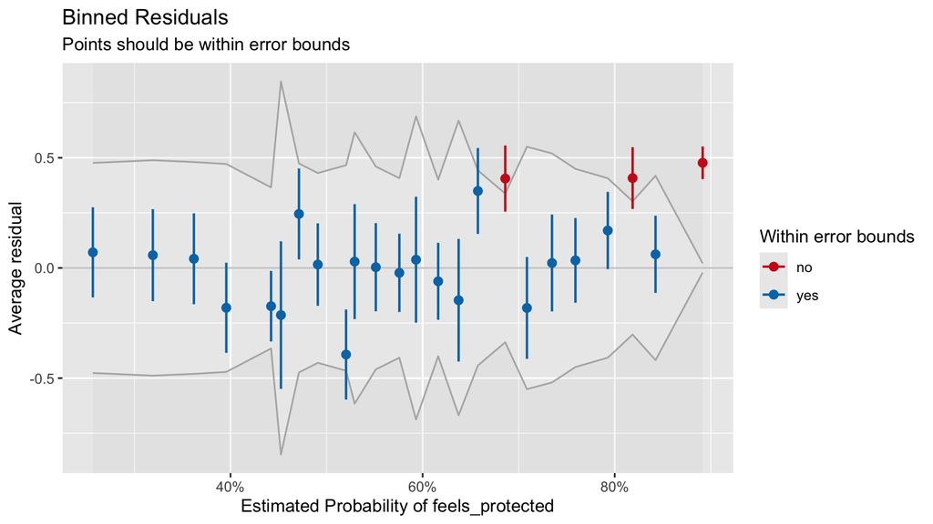

Figure 2. Binned residuals against the fitted probability of feeling protected. Grey band is the 95% error bound; points outside it are shown in red.

For a logistic model the relevant panels are the binned residual plot, collinearity and influential observations; normality of residuals and homogeneity of variance are linear-model assumptions and do not apply to a binary outcome, so they are neither produced nor interpreted here.

*Binned residuals.* Every predictor in this model is categorical, so there is no linear-in-the-logit assumption to violate in the usual sense — each predictor is fitted saturated, and the model can only misfit through omitted interactions. 88% of the 24 bins fall inside the error bounds, against the 95% one would like to see, and the bins that fall outside sit at the top of the predicted-probability range with positive residuals (largest average residual 0.48 at a mean fitted probability of 0.89). In other words the model slightly under-predicts the probability of feeling protected among the respondents it already rates most likely to feel protected — the signature of an omitted interaction, most plausibly management role by sector. There is no systematic curvature across the range, so this is a mild misfit rather than a structural failure, but it is worth reporting rather than declaring clean.

*Collinearity.* All VIFs are low. The largest are `country_grp` (1.69) and `sector_grp` (1.6), reflecting the fact that recruitment was country- and sector-specific at once, but both are far below any threshold of concern.

*Influential observations.* The largest Cook’s distance is 0.0117, orders of magnitude below the usual 0.5 or 1 cut-offs, and no point crosses the contour in the influence panel. With 557 rows and only categorical predictors, no single respondent can move an estimate.

*Separation and cell sizes.* Every coefficient in the fitted model is finite with a finite confidence interval, and the smallest predictor-by-outcome cell anywhere in the fitted model is 25 (vaccine refusal, not feeling protected), so there is no separation and no zero cell. This is precisely what the collapsing bought: the uncollapsed model has a cell of size 1 (manufacturing, not feeling protected), which is quasi-separation in all but name.

*Events per parameter* is 19.2, adequate.

# Discussion

Among workers in this international convenience sample, three things are independently associated with feeling protected from COVID-19 at work: being a manager, being a man, and not working in education. The management association is the strongest and the most stable — managers have 3.2 times the adjusted odds of non-managers — and it is barely touched by adjustment for sex, age, sector or country. Practically this says that the people who design and communicate workplace COVID-19 controls are considerably more confident in them than the people subject to them, which is a finding about organisational communication rather than about the controls themselves. The original questionnaire validation paper reported the same pattern for men, older workers and managerial staff, so this analysis reproduces it rather than adding to it.

What the data do *not* show is any association between vaccination status and feeling protected: neither lacking access to a vaccine nor refusing one shifts the odds (joint p = 0.21). Personal vaccination and perceived workplace protection appear to be separate judgements. Overall discrimination is weak (Tjur’s R² = 0.115), so these are descriptions of associations in one sample, not a model that would predict anything.

**Limitations.** The sampling is the central problem. Respondents were recruited online by non-probability convenience sampling across eight countries, and 77% of them are in Canada or Ireland while 41% work in health care. There is no sampling frame and no weighting, so the results generalise to nobody in particular: they describe these 557 volunteers and no identifiable population. Country contrasts in particular should not be read as national differences, because the composition of each country’s respondents differs in ways the file cannot capture. Second, sparse categories forced collapsing: `country` went from 7 levels to 3 and `occupational_sector` from 10 to 3, and the uncollapsed model fits significantly better (p = 0.003), so real heterogeneity has been averaged away. The “other country” bucket is especially heterogeneous — the United Kingdom is at 39% feeling protected and China at 79%, and pooling them into one coefficient is a compromise, not a description. Third, the outcome is a single self-reported yes/no item collected at the same sitting as the predictors; it measures perception, not the presence or quality of any actual control measure, and no measure of the workplace’s actual protective measures is available in this file. Fourth, the design is cross-sectional, so nothing here is causal — becoming a manager may raise confidence, or confident people may become managers. Fifth, all the obvious confounders of the management association (seniority, income, whether the job is remote-capable, workplace size, timing relative to local case waves) are absent from the file, so residual confounding is likely. The one thing that is *not* a limitation is missing data: the file is 100% complete on all columns.

**Future work.** Linking these perception data to an objective audit of the control measures actually in place would show whether the manager-worker gap reflects better-protected managers or merely better-informed ones.

# Feasibility notes

*Not part of a student report.*

- **The outcome works.** 326 protected versus 231 not, out of 557 complete cases — a 59/41 split, 231 in the rarer class. With the collapsed predictor set the model has 12 coefficients and 19.2 events per parameter, max VIF 1.69, max Cook’s distance 0.0117, no separation. Nothing breaks.
- **Sparse categories are the real hazard, and a student will hit them.** `country` (7 levels, 4 with n < 25) and `occupational_sector` (10 levels, 7 with n < 28) are the two most tempting predictors in the file and both are unusable raw. The uncollapsed model has 23 coefficients, 10 events per parameter, a 1-vs-12 outcome cell in manufacturing, and confidence intervals spanning up to a 111-fold range. The brief must tell students to collapse, or they will report an odds ratio of 2.3 with a straight face.
- **Collapsing is not free.** The uncollapsed model has the *lower* AIC (706.6 versus 713.1) and the likelihood-ratio test favours it (p = 0.003). A sharp student will notice this and needs a defensible answer: precision and interpretability versus fit, decided before seeing the models. Instructors should be ready for the question.
- **Weak signal, and the confounding story is thin.** Tjur’s R² = 0.115. Only three of seven predictors are significant after adjustment, and the two strongest — management role and sex — move by no more than about 7% on adjustment. The unadjusted-versus-adjusted comparison is therefore much less instructive here than in datasets where crude associations collapse; the only real movers are the education-sector contrast (which moves *away* from the null, from 0.44 to 0.32) and the 45-55 age band (1.63 to 1.51, losing significance).
- **The most interesting predictor is null.** `vaccination_status` is the variable students will want to write about, and it does nothing: joint LRT p = 0.21, both levels’ intervals straddling 1 crudely and adjusted. It must not be collapsed to vaccinated/unvaccinated to manufacture a result — no access and refusal are different states — and a student who does so is answering a worse question.
- **No missing data at all.** Every column is 100% complete, so this dataset cannot be used to teach missingness, complete-case bias or imputation.
- **One outcome only.** `feels_protected` is the sole outcome column; the other seven usable columns are all categorical predictors and none is continuous. There is no linear-regression option, no second logistic outcome, and no continuous predictor, so students cannot practise per-unit interpretation, linearity checks, or a continuous-outcome workflow. A whole project on this file is one model, repeated.
- **Convenience sample across eight countries.** No sampling frame, no weights, 77% Canada or Ireland, 41% health care. Any generalisation statement a student writes will be wrong unless it is “these respondents only”.
- **Also note:** the source paper analyses 627 active workers; the deposited sheet used here supplies 557. Students comparing their output to the paper will not reproduce it exactly.